# PLS - Hoteles

Artículo 1, versión 1 (Doctoranda Moreno)

Roberto Gil-Saura

2021-06-02

### 0.0.1 Notas

Valorar RVL, pues funciona muy mal en el modelo.

# 1 Análisis del modelo de medida, multigrupo.

Seguidamente mostramos el modelo estructural (*inner model*), establecidos a partir de las hipótesis lanzadas. A lo largo del documento se muestra el modelo general y el modelo multigrupo generado a partir de variable ORIENTACION AL CLIENTE. Sobre la misma se ha generado una clasificación entre ALTA y BAJA, utilizando el criterio de la mediana para realizar la partición. Esta partición se ha validado utilizando también el análisis CLUSTER, donde la optimización de grupos mostraba también como solución satisfactoria los dos grupos, y los criterios KMEANS, PAM y CLARA han mostrado una gran coherencia con esa clasificación inicial.

El modelo estructural es el siguiente:

[interactive chart not shown]

Modelo estructural

[figure not shown]

Modelo

## 1.1 Fiabilidad del instrumento de medida

Para el modelo de medida se han considerado constructos de tipo composite mode_A (reflectivos). De este modo, el primer paso debe ser observar el resumen de los indicadores de fiabilidad, consistencia interna y validez.

Comenzamos viendo el *Cronbach’s alpha*, y el resultado del análisis muestra todas las escalas que apoyan las variables latentes tienen un mayor que 0.7, completado por una fiabilidad del compuesto *rhoC* también por encima de 0.7. para valores superiores a 0.9[^1].

```
Modelo
```

```
    alpha  rhoC   AVE  rhoA
ICT 0.855 0.899 0.692 0.944
SUS 0.945 0.947 0.523 0.984
BEQ 0.954 0.967 0.878 0.959
SST 0.856 0.913 0.777 0.872
EST 0.825 0.896 0.742 0.833

Alpha, rhoC, and rhoA should exceed 0.7 while AVE should exceed 0.5
```

```
Modelo grupo 1
```

```
    alpha  rhoC   AVE  rhoA
ICT 0.837 0.891 0.674 0.896
SUS 0.942 0.946 0.518 0.982
BEQ 0.965 0.974 0.904 0.978
SST 0.817 0.891 0.732 0.843
EST 0.848 0.908 0.768 0.854

Alpha, rhoC, and rhoA should exceed 0.7 while AVE should exceed 0.5
```

```
Modelo grupo 2
```

```
    alpha  rhoC   AVE  rhoA
ICT 0.855 0.892 0.678 1.032
SUS 0.936 0.927 0.454 0.946
BEQ 0.942 0.958 0.852 0.946
SST 0.892 0.933 0.822 0.898
EST 0.795 0.880 0.710 0.811

Alpha, rhoC, and rhoA should exceed 0.7 while AVE should exceed 0.5
```

## 1.2 Validez convergente

### 1.2.1 AVE (constructos reflectivos)

El AVE (*average variance extracted*) se define como la cantidad de varianza que un constructo obtiene de sus indicadores con relación a la cantidad de varianza debida al error de medida, recomendándose que su valor sea superior a 0,50 lo que implica que más del 50% de la varianza del constructo es debida a sus indicadores (Fornell y Larcker, 1981).

```
Modelo
```

```
  ICT   SUS   BEQ   SST   EST
0.692 0.523 0.878 0.777 0.742
```

```
Modelo grupo 1
```

```
  ICT   SUS   BEQ   SST   EST
0.674 0.518 0.904 0.732 0.768
```

```
Modelo grupo 2
```

```
  ICT   SUS   BEQ   SST   EST
0.678 0.454 0.852 0.822 0.710
```

Los indicadores son mostrados de forma conjunta en el siguiente gráfico.

```
Modelo
```

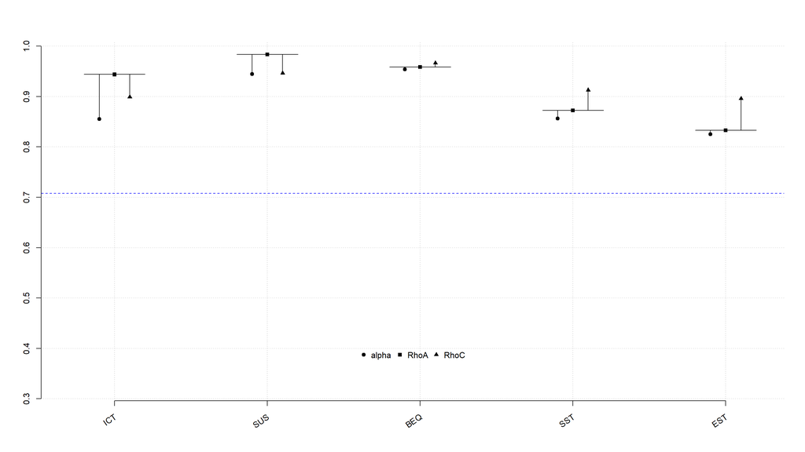

Tabla de fiabilidad

```
Modelo grupo 1
```

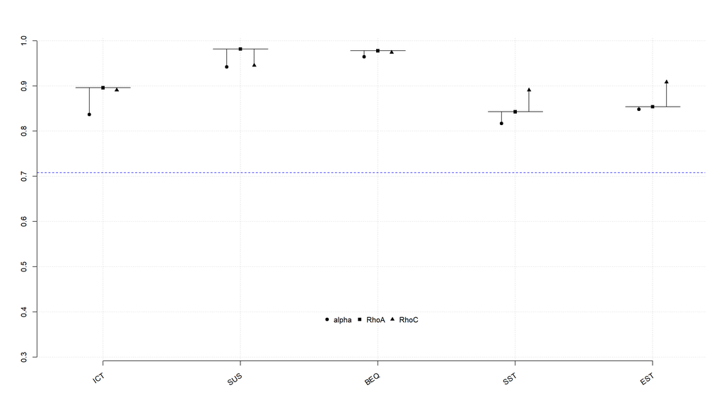

Tabla de fiabilidad

```
Modelo grupo 2
```

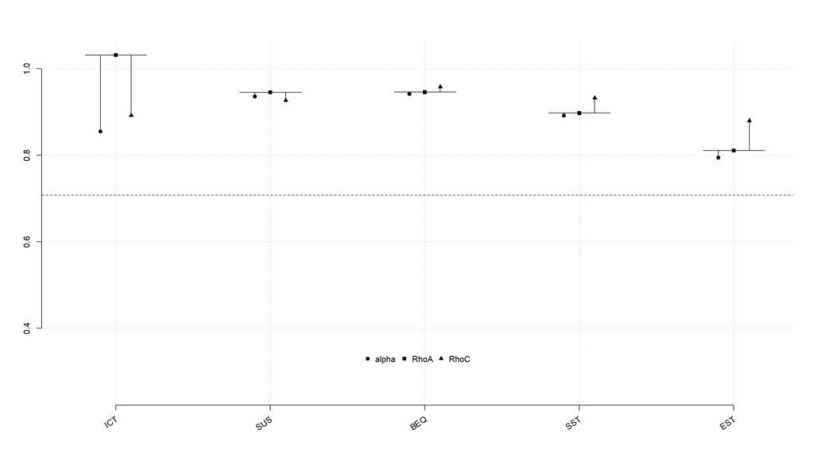

Tabla de fiabilidad

### 1.2.2 Análisis de las cargas (reflectivos) o de los pesos (formativos)

Para la valoración de la validez convergente se analiza también el tamaño de las cargas de los indicadores.

El tamaño de las cargas también es considerado un indicador de fiabilidad; es por ello que todas las cargas de todos los indicadores deberían ser estadísticamente significativas y además su tamaño ser igual o superior[^2] al valor 0,708. Las cargas elevadas sobre un constructo, señalan que los indicadores asociados con el mismo tienen mucho en común y, por lo tanto, capturan correctamente la variable latente. Para aquellas cargas que están entre 0.4 y 0.7 debe ser analizado el comportamiento del constructo ante una eliminación del indicador con carga baja[^3].

```
Modelo
```

```
        ICT   SUS   BEQ   SST   EST  SUSA  SUSB  SUSC
ICT1  0.816 0.000 0.000 0.000 0.000 0.000 0.000 0.000
ICT2  0.905 0.000 0.000 0.000 0.000 0.000 0.000 0.000
ICT3  0.904 0.000 0.000 0.000 0.000 0.000 0.000 0.000
ICT4  0.683 0.000 0.000 0.000 0.000 0.000 0.000 0.000
SUSA  0.000 0.907 0.000 0.000 0.000 0.000 0.000 0.000
SUSB  0.000 0.905 0.000 0.000 0.000 0.000 0.000 0.000
SUSC  0.000 0.485 0.000 0.000 0.000 0.000 0.000 0.000
SUS1  0.000 0.756 0.000 0.000 0.000 1.000 0.000 0.000
SUS2  0.000 0.787 0.000 0.000 0.000 1.000 0.000 0.000
SUS3  0.000 0.716 0.000 0.000 0.000 1.000 0.000 0.000
SUS4  0.000 0.686 0.000 0.000 0.000 1.000 0.000 0.000
SUS5  0.000 0.676 0.000 0.000 0.000 1.000 0.000 0.000
SUS6  0.000 0.810 0.000 0.000 0.000 1.000 0.000 0.000
SUS7  0.000 0.689 0.000 0.000 0.000 1.000 0.000 0.000
SUS8  0.000 0.655 0.000 0.000 0.000 1.000 0.000 0.000
SUS10 0.000 0.835 0.000 0.000 0.000 0.000 1.000 0.000
SUS11 0.000 0.872 0.000 0.000 0.000 0.000 1.000 0.000
SUS12 0.000 0.857 0.000 0.000 0.000 0.000 1.000 0.000
SUS13 0.000 0.460 0.000 0.000 0.000 0.000 0.000 1.000
SUS14 0.000 0.426 0.000 0.000 0.000 0.000 0.000 1.000
SUS15 0.000 0.477 0.000 0.000 0.000 0.000 0.000 1.000
BEQ7  0.000 0.000 0.897 0.000 0.000 0.000 0.000 0.000
BEQ8  0.000 0.000 0.939 0.000 0.000 0.000 0.000 0.000
BEQ9  0.000 0.000 0.956 0.000 0.000 0.000 0.000 0.000
BEQ10 0.000 0.000 0.955 0.000 0.000 0.000 0.000 0.000
SST1  0.000 0.000 0.000 0.818 0.000 0.000 0.000 0.000
SST2  0.000 0.000 0.000 0.929 0.000 0.000 0.000 0.000
SST3  0.000 0.000 0.000 0.894 0.000 0.000 0.000 0.000
EST1  0.000 0.000 0.000 0.000 0.858 0.000 0.000 0.000
EST2  0.000 0.000 0.000 0.000 0.904 0.000 0.000 0.000
EST3  0.000 0.000 0.000 0.000 0.819 0.000 0.000 0.000
```

```
Modelo grupo 1
```

```
        ICT   SUS   BEQ   SST    EST  SUSA  SUSB  SUSC
ICT1  0.855 0.000 0.000 0.000  0.000 0.000 0.000 0.000
ICT2  0.897 0.000 0.000 0.000  0.000 0.000 0.000 0.000
ICT3  0.872 0.000 0.000 0.000 -0.000 0.000 0.000 0.000
ICT4  0.633 0.000 0.000 0.000  0.000 0.000 0.000 0.000
SUSA  0.000 0.913 0.000 0.000  0.000 0.000 0.000 0.000
SUSB  0.000 0.891 0.000 0.000  0.000 0.000 0.000 0.000
SUSC  0.000 0.479 0.000 0.000  0.000 0.000 0.000 0.000
SUS1  0.000 0.777 0.000 0.000  0.000 1.000 0.000 0.000
SUS2  0.000 0.792 0.000 0.000  0.000 1.000 0.000 0.000
SUS3  0.000 0.732 0.000 0.000  0.000 1.000 0.000 0.000
SUS4  0.000 0.733 0.000 0.000  0.000 1.000 0.000 0.000
SUS5  0.000 0.657 0.000 0.000  0.000 1.000 0.000 0.000
SUS6  0.000 0.820 0.000 0.000  0.000 1.000 0.000 0.000
SUS7  0.000 0.665 0.000 0.000  0.000 1.000 0.000 0.000
SUS8  0.000 0.640 0.000 0.000  0.000 1.000 0.000 0.000
SUS10 0.000 0.815 0.000 0.000  0.000 0.000 1.000 0.000
SUS11 0.000 0.856 0.000 0.000  0.000 0.000 1.000 0.000
SUS12 0.000 0.845 0.000 0.000  0.000 0.000 1.000 0.000
SUS13 0.000 0.451 0.000 0.000  0.000 0.000 0.000 1.000
SUS14 0.000 0.432 0.000 0.000  0.000 0.000 0.000 1.000
SUS15 0.000 0.436 0.000 0.000  0.000 0.000 0.000 1.000
BEQ7  0.000 0.000 0.908 0.000  0.000 0.000 0.000 0.000
BEQ8  0.000 0.000 0.942 0.000  0.000 0.000 0.000 0.000
BEQ9  0.000 0.000 0.977 0.000  0.000 0.000 0.000 0.000
BEQ10 0.000 0.000 0.975 0.000  0.000 0.000 0.000 0.000
SST1  0.000 0.000 0.000 0.765  0.000 0.000 0.000 0.000
SST2  0.000 0.000 0.000 0.919  0.000 0.000 0.000 0.000
SST3  0.000 0.000 0.000 0.876  0.000 0.000 0.000 0.000
EST1  0.000 0.000 0.000 0.000  0.898 0.000 0.000 0.000
EST2  0.000 0.000 0.000 0.000  0.896 0.000 0.000 0.000
EST3  0.000 0.000 0.000 0.000  0.833 0.000 0.000 0.000
```

```
Modelo grupo 2
```

```
         ICT   SUS    BEQ   SST    EST  SUSA  SUSB  SUSC
ICT1   0.706 0.000  0.000 0.000  0.000 0.000 0.000 0.000
ICT2   0.917 0.000  0.000 0.000  0.000 0.000 0.000 0.000
ICT3   0.941 0.000  0.000 0.000 -0.000 0.000 0.000 0.000
ICT4   0.700 0.000  0.000 0.000 -0.000 0.000 0.000 0.000
SUSA   0.000 0.872  0.000 0.000  0.000 0.000 0.000 0.000
SUSB   0.000 0.901  0.000 0.000  0.000 0.000 0.000 0.000
SUSC   0.000 0.298 -0.000 0.000  0.000 0.000 0.000 0.000
SUS1   0.000 0.646  0.000 0.000  0.000 1.000 0.000 0.000
SUS2   0.000 0.713  0.000 0.000  0.000 1.000 0.000 0.000
SUS3   0.000 0.639 -0.000 0.000  0.000 1.000 0.000 0.000
SUS4   0.000 0.615  0.000 0.000  0.000 1.000 0.000 0.000
SUS5   0.000 0.703  0.000 0.000 -0.000 1.000 0.000 0.000
SUS6   0.000 0.787  0.000 0.000 -0.000 1.000 0.000 0.000
SUS7   0.000 0.706  0.000 0.000 -0.000 1.000 0.000 0.000
SUS8   0.000 0.604  0.000 0.000  0.000 1.000 0.000 0.000
SUS10  0.000 0.803  0.000 0.000  0.000 0.000 1.000 0.000
SUS11  0.000 0.858  0.000 0.000  0.000 0.000 1.000 0.000
SUS12  0.000 0.850  0.000 0.000  0.000 0.000 1.000 0.000
SUS13  0.000 0.286 -0.000 0.000  0.000 0.000 0.000 1.000
SUS14  0.000 0.269 -0.000 0.000  0.000 0.000 0.000 1.000
SUS15  0.000 0.325 -0.000 0.000  0.000 0.000 0.000 1.000
BEQ7   0.000 0.000  0.888 0.000  0.000 0.000 0.000 0.000
BEQ8   0.000 0.000  0.936 0.000  0.000 0.000 0.000 0.000
BEQ9   0.000 0.000  0.934 0.000  0.000 0.000 0.000 0.000
BEQ10  0.000 0.000  0.934 0.000  0.000 0.000 0.000 0.000
SST1   0.000 0.000  0.000 0.868  0.000 0.000 0.000 0.000
SST2   0.000 0.000  0.000 0.938  0.000 0.000 0.000 0.000
SST3   0.000 0.000  0.000 0.914  0.000 0.000 0.000 0.000
EST1  -0.000 0.000  0.000 0.000  0.806 0.000 0.000 0.000
EST2   0.000 0.000  0.000 0.000  0.911 0.000 0.000 0.000
EST3   0.000 0.000  0.000 0.000  0.807 0.000 0.000 0.000
```

## 1.3 Validez discriminante

### 1.3.1 Cross-loadings

Para el análisis de la validez discriminante o capacidad de un constructo de ser realmente distinto a otros, utilizamos las denominadas *cross-loadings*, que miden esa capacidad del constructo. En la tabla adjunta se puede observar en cada indicador carga de forma superior en su variable latente, siendo el resto de cargas de menor intensidad.

```
Modelo
```

```
        ICT   SUS   BEQ   SST   EST
ICT1  0.816 0.377 0.131 0.127 0.081
ICT2  0.905 0.402 0.236 0.168 0.110
ICT3  0.904 0.385 0.277 0.110 0.011
ICT4  0.683 0.363 0.129 0.176 0.051
SUSA  0.369 0.907 0.185 0.237 0.169
SUSB  0.455 0.905 0.282 0.338 0.223
SUSC  0.189 0.485 0.044 0.134 0.121
SUS1  0.283 0.756 0.165 0.225 0.218
SUS2  0.347 0.787 0.144 0.173 0.162
SUS3  0.289 0.716 0.039 0.203 0.143
SUS4  0.275 0.686 0.107 0.237 0.195
SUS5  0.235 0.676 0.166 0.198 0.112
SUS6  0.348 0.810 0.178 0.230 0.104
SUS7  0.316 0.689 0.164 0.104 0.035
SUS8  0.250 0.655 0.110 0.165 0.151
SUS10 0.422 0.835 0.209 0.299 0.201
SUS11 0.432 0.872 0.262 0.309 0.214
SUS12 0.434 0.857 0.309 0.344 0.214
SUS13 0.128 0.460 0.023 0.126 0.104
SUS14 0.165 0.426 0.049 0.143 0.140
SUS15 0.217 0.477 0.040 0.101 0.084
BEQ7  0.222 0.255 0.897 0.323 0.336
BEQ8  0.197 0.177 0.939 0.268 0.277
BEQ9  0.250 0.231 0.956 0.260 0.276
BEQ10 0.270 0.265 0.955 0.277 0.248
SST1  0.195 0.310 0.269 0.818 0.557
SST2  0.136 0.292 0.237 0.929 0.725
SST3  0.120 0.243 0.296 0.894 0.738
EST1  0.035 0.168 0.221 0.630 0.858
EST2  0.112 0.225 0.244 0.725 0.904
EST3  0.026 0.162 0.326 0.631 0.819
```

```
Modelo grupo 1
```

```
        ICT   SUS   BEQ   SST    EST
ICT1  0.855 0.349 0.147 0.106  0.063
ICT2  0.897 0.413 0.246 0.100  0.049
ICT3  0.872 0.396 0.275 0.068 -0.022
ICT4  0.633 0.414 0.153 0.159  0.086
SUSA  0.409 0.913 0.188 0.262  0.244
SUSB  0.461 0.891 0.271 0.283  0.180
SUSC  0.191 0.479 0.066 0.117  0.125
SUS1  0.283 0.777 0.166 0.205  0.212
SUS2  0.366 0.792 0.196 0.201  0.215
SUS3  0.303 0.732 0.086 0.264  0.216
SUS4  0.303 0.733 0.113 0.253  0.229
SUS5  0.262 0.657 0.163 0.264  0.249
SUS6  0.445 0.820 0.190 0.257  0.159
SUS7  0.367 0.665 0.083 0.053  0.068
SUS8  0.269 0.640 0.113 0.128  0.192
SUS10 0.435 0.815 0.188 0.190  0.119
SUS11 0.423 0.856 0.239 0.256  0.188
SUS12 0.446 0.845 0.311 0.323  0.186
SUS13 0.118 0.451 0.038 0.128  0.088
SUS14 0.188 0.432 0.081 0.117  0.153
SUS15 0.207 0.436 0.037 0.060  0.054
BEQ7  0.273 0.208 0.908 0.182  0.237
BEQ8  0.174 0.190 0.942 0.119  0.135
BEQ9  0.259 0.245 0.977 0.149  0.149
BEQ10 0.281 0.278 0.975 0.129  0.115
SST1  0.193 0.318 0.076 0.765  0.519
SST2  0.091 0.262 0.118 0.919  0.678
SST3  0.055 0.209 0.187 0.876  0.719
EST1  0.013 0.192 0.150 0.676  0.898
EST2  0.072 0.251 0.120 0.697  0.896
EST3  0.022 0.180 0.178 0.608  0.833
```

```
Modelo grupo 2
```

```
         ICT   SUS    BEQ   SST    EST
ICT1   0.706 0.325  0.078 0.132  0.053
ICT2   0.917 0.274  0.197 0.242  0.153
ICT3   0.941 0.263  0.252 0.126 -0.009
ICT4   0.700 0.205  0.074 0.175 -0.031
SUSA   0.208 0.872  0.193 0.216  0.040
SUSB   0.320 0.901  0.271 0.403  0.227
SUSC   0.026 0.298 -0.035 0.133  0.084
SUS1   0.164 0.646  0.130 0.236  0.183
SUS2   0.220 0.713  0.051 0.124  0.050
SUS3   0.188 0.639 -0.043 0.128  0.024
SUS4   0.189 0.615  0.078 0.208  0.131
SUS5   0.163 0.703  0.152 0.133 -0.040
SUS6   0.129 0.787  0.134 0.188 -0.000
SUS7   0.188 0.706  0.220 0.134 -0.035
SUS8   0.125 0.604  0.078 0.193  0.051
SUS10  0.265 0.803  0.197 0.415  0.250
SUS11  0.316 0.858  0.259 0.358  0.195
SUS12  0.306 0.850  0.285 0.366  0.199
SUS13  0.004 0.286 -0.042 0.103  0.078
SUS14  0.036 0.269 -0.027 0.164  0.089
SUS15  0.086 0.325 -0.009 0.126  0.066
BEQ7   0.145 0.325  0.888 0.453  0.436
BEQ8   0.205 0.181  0.936 0.405  0.422
BEQ9   0.223 0.227  0.934 0.359  0.404
BEQ10  0.234 0.256  0.934 0.404  0.374
SST1   0.205 0.344  0.460 0.868  0.601
SST2   0.177 0.351  0.353 0.938  0.781
SST3   0.155 0.275  0.400 0.914  0.759
EST1  -0.007 0.082  0.279 0.582  0.806
EST2   0.124 0.165  0.366 0.750  0.911
EST3   0.009 0.137  0.473 0.654  0.807
```

### 1.3.2 Fornell-Larcker

El criterio de Fornell-Larcker, compara la raíz cuadrado del *AVE* con la correlación de las variables latentes. La raíz cuadrada del *AVE* de cada constructo, debería ser más grande que la más alta correlación con cualquier otro constructo. Se puede observar en la tabla siguiente que el valor en la diagonal principal, es mayor que el resto de valores en la parte inferior de la matriz.

```
Modelo
```

```
      ICT   SUS   BEQ   SST   EST
ICT 0.832     .     .     .     .
SUS 0.452 0.723     .     .     .
BEQ 0.252 0.251 0.937     .     .
SST 0.166 0.315 0.303 0.882     .
EST 0.070 0.217 0.305 0.771 0.861

FL Criteria table reports square root of AVE on the diagonal and construct correlations on the lower triangle.
```

```
Modelo grupo 1
```

```
      ICT   SUS   BEQ   SST   EST
ICT 0.821     .     .     .     .
SUS 0.476 0.720     .     .     .
BEQ 0.265 0.246 0.951     .     .
SST 0.122 0.298 0.154 0.856     .
EST 0.042 0.238 0.169 0.756 0.876

FL Criteria table reports square root of AVE on the diagonal and construct correlations on the lower triangle.
```

```
Modelo grupo 2
```

```
      ICT   SUS   BEQ   SST   EST
ICT 0.824     .     .     .     .
SUS 0.307 0.674     .     .     .
BEQ 0.217 0.272 0.923     .     .
SST 0.196 0.355 0.442 0.907     .
EST 0.056 0.156 0.444 0.791 0.843

FL Criteria table reports square root of AVE on the diagonal and construct correlations on the lower triangle.
```

### 1.3.3 HTMT

Por último el HTMT es un ratio que si es mayor que 0.90 indica una pérdida de validez discriminante. El ratio HTMT nos indica que los indicadores que pertenecen a una determinada variables latente están correlacionando más como otra variable latente que con la propia. HT/MT> 0.85 Clark & Watson, > 0.90 Gold et al. 2001; Teo et al. 2008).

```
Modelo
```

```
      ICT   SUS   BEQ   SST EST
ICT     .     .     .     .   .
SUS 0.473     .     .     .   .
BEQ 0.254 0.207     .     .   .
SST 0.210 0.324 0.334     .   .
EST 0.098 0.235 0.344 0.907   .
```

```
Modelo grupo 1
```

```
      ICT   SUS   BEQ   SST EST
ICT     .     .     .     .   .
SUS 0.511     .     .     .   .
BEQ 0.272 0.213     .     .   .
SST 0.174 0.327 0.165     .   .
EST 0.086 0.261 0.187 0.895   .
```

```
Modelo grupo 2
```

```
      ICT   SUS   BEQ   SST EST
ICT     .     .     .     .   .
SUS 0.300     .     .     .   .
BEQ 0.202 0.198     .     .   .
SST 0.234 0.333 0.483     .   .
EST 0.129 0.182 0.510 0.929   .
```

# 2 Análisis del modelo estructural

Una vez analizados los constructos desde el punto de vista de su composición, debemos analizar el modelo estructural en su conjunto. Partiendo de que el objetivo del PLS es la maximización de la varianza explicada, las medidas más importantes son la fiabilidad, la validez convergente y la validez discriminante del conjunto del modelo.

- Paths o cargas de latentes…
- R<sup>2</sup>, coeficiente de determinación y/o % de varianza explicada
- f<sup>2</sup> y q<sup>2</sup> efecto tamaño
- Q<sup>2</sup>, relevancia predictiva

## 2.1 Paths y R<sup>2</sup>

```
Modelo
```

```
         BEQ   SST   EST
R^2    0.087 0.092 0.595
AdjR^2 0.080 0.088 0.593
ICT    0.174     .     .
SUS    0.172     .     .
BEQ        . 0.303     .
SST        .     . 0.771
```

```
Modelo grupo 1
```

```
         BEQ   SST   EST
R^2    0.089 0.024 0.571
AdjR^2 0.077 0.017 0.568
ICT    0.192     .     .
SUS    0.154     .     .
BEQ        . 0.154     .
SST        .     . 0.756
```

```
Modelo grupo 2
```

```
         BEQ   SST   EST
R^2    0.094 0.196 0.626
AdjR^2 0.077 0.188 0.622
ICT    0.147     .     .
SUS    0.227     .     .
BEQ        . 0.442     .
SST        .     . 0.791
```

## 2.2 f² - Tamaño del efecto

El f² permite evaluar la contribución de cada constructo exógeno a la R² de un constructo endógeno. Los valores de 0.02, 0.15 y 0.35 indican un efecto pequeño, mediano o grande sobre el constructo endógeno.

```
Modelo
```

```
      ICT   SUS   BEQ   SST   EST
ICT 0.000 0.000 0.026 0.000 0.000
SUS 0.000 0.000 0.026 0.000 0.000
BEQ 0.000 0.000 0.000 0.101 0.000
SST 0.000 0.000 0.000 0.000 1.467
EST 0.000 0.000 0.000 0.000 0.000
```

```
Modelo grupo 1
```

```
      ICT   SUS   BEQ   SST   EST
ICT 0.000 0.000 0.031 0.000 0.000
SUS 0.000 0.000 0.020 0.000 0.000
BEQ 0.000 0.000 0.000 0.024 0.000
SST 0.000 0.000 0.000 0.000 1.331
EST 0.000 0.000 0.000 0.000 0.000
```

```
Modelo grupo 2
```

```
      ICT   SUS   BEQ   SST   EST
ICT 0.000 0.000 0.021 0.000 0.000
SUS 0.000 0.000 0.051 0.000 0.000
BEQ 0.000 0.000 0.000 0.243 0.000
SST 0.000 0.000 0.000 0.000 1.673
EST 0.000 0.000 0.000 0.000 0.000
```

## 2.3 Efectos

### 2.3.1 Totales

```
Modelo
```

```
      ICT   SUS   BEQ   SST   EST
ICT 0.000 0.000 0.174 0.053 0.041
SUS 0.000 0.000 0.172 0.052 0.040
BEQ 0.000 0.000 0.000 0.303 0.233
SST 0.000 0.000 0.000 0.000 0.771
EST 0.000 0.000 0.000 0.000 0.000
```

```
Modelo grupo 1
```

```
      ICT   SUS   BEQ   SST   EST
ICT 0.000 0.000 0.192 0.030 0.022
SUS 0.000 0.000 0.154 0.024 0.018
BEQ 0.000 0.000 0.000 0.154 0.116
SST 0.000 0.000 0.000 0.000 0.756
EST 0.000 0.000 0.000 0.000 0.000
```

```
Modelo grupo 2
```

```
      ICT   SUS   BEQ   SST   EST
ICT 0.000 0.000 0.147 0.065 0.052
SUS 0.000 0.000 0.227 0.101 0.080
BEQ 0.000 0.000 0.000 0.442 0.350
SST 0.000 0.000 0.000 0.000 0.791
EST 0.000 0.000 0.000 0.000 0.000
```

### 2.3.2 Indirectos

```
Modelo
```

```
      ICT   SUS   BEQ   SST   EST
ICT 0.000 0.000 0.000 0.053 0.041
SUS 0.000 0.000 0.000 0.052 0.040
BEQ 0.000 0.000 0.000 0.000 0.233
SST 0.000 0.000 0.000 0.000 0.000
EST 0.000 0.000 0.000 0.000 0.000
```

```
Modelo grupo 1
```

```
      ICT   SUS   BEQ   SST   EST
ICT 0.000 0.000 0.000 0.030 0.022
SUS 0.000 0.000 0.000 0.024 0.018
BEQ 0.000 0.000 0.000 0.000 0.116
SST 0.000 0.000 0.000 0.000 0.000
EST 0.000 0.000 0.000 0.000 0.000
```

```
Modelo grupo 2
```

```
      ICT   SUS   BEQ   SST   EST
ICT 0.000 0.000 0.000 0.065 0.052
SUS 0.000 0.000 0.000 0.101 0.080
BEQ 0.000 0.000 0.000 0.000 0.350
SST 0.000 0.000 0.000 0.000 0.000
EST 0.000 0.000 0.000 0.000 0.000
```

### 2.3.3 it_criteria

```
Modelo
```

```
        BEQ     SST      EST
AIC -19.404 -22.747 -238.998
BIC  -8.631 -15.565 -231.816
```

```
Modelo grupo 1
```

```
       BEQ    SST      EST
AIC -9.596 -0.775 -129.850
BIC -0.428  5.337 -123.738
```

```
Modelo grupo 2
```

```
       BEQ     SST      EST
AIC -5.935 -21.189 -106.151
BIC  2.193 -15.770 -100.732
```

# 3 Modelización con bootstrapping

*Bootstrapping* para calcular la significatividad de los paths estimados y del resto de elementos que usamos para la validación. Habitualmente se trabaja con un 5% (t > 1.96) lo que implica significatividad al 95%. Podemos cambiar al 10 o al 1 según ámbito. Usar doble *bootstrapping* si hay menos de 4 constructos.

## 3.1 Bootstrapped Structural paths

Conjunto de coeficiente path con intervalo de confianza. Los intervalos de confianza no deben contener el 0 para ser significativos.

```
Modelo
```

```
             Original Est. Bootstrap Mean Bootstrap SD T Stat. 2.5% CI 97.5% CI
ICT  ->  BEQ         0.174          0.162        0.061   2.868   0.059    0.279
SUS  ->  BEQ         0.172          0.207        0.058   2.992   0.115    0.309
BEQ  ->  SST         0.303          0.303        0.064   4.715   0.147    0.409
SST  ->  EST         0.771          0.769        0.034  22.768   0.716    0.833
```

```
Modelo grupo 1
```

```
             Original Est. Bootstrap Mean Bootstrap SD T Stat. 2.5% CI 97.5% CI
ICT  ->  BEQ         0.192          0.190        0.079   2.441   0.028    0.339
SUS  ->  BEQ         0.154          0.189        0.072   2.134   0.059    0.335
BEQ  ->  SST         0.154          0.152        0.082   1.869  -0.004    0.280
SST  ->  EST         0.756          0.764        0.043  17.747   0.678    0.836
```

```
Modelo grupo 2
```

```
             Original Est. Bootstrap Mean Bootstrap SD T Stat. 2.5% CI 97.5% CI
ICT  ->  BEQ         0.147          0.149        0.092   1.609  -0.035    0.307
SUS  ->  BEQ         0.227          0.279        0.161   1.412  -0.304    0.463
BEQ  ->  SST         0.442          0.460        0.073   6.091   0.324    0.582
SST  ->  EST         0.791          0.804        0.044  17.839   0.723    0.898
```

## 3.2 Bootstrapped loadings

Cargas (modelo con constructos reflectivos) con intervalo de confianza. Las cargas deberían ser significativas y mayores a 0.708 dado que este número al cuadrado es 0.50 (Hair et al. 2017).

```
Modelo
```

```
                Original Est. Bootstrap Mean Bootstrap SD T Stat. 2.5% CI 97.5% CI
ICT1  ->  ICT           0.816          0.800        0.048  17.022   0.700    0.877
ICT2  ->  ICT           0.905          0.900        0.021  43.277   0.854    0.926
ICT3  ->  ICT           0.904          0.901        0.021  42.788   0.859    0.939
ICT4  ->  ICT           0.683          0.670        0.078   8.725   0.542    0.776
SUSA  ->  SUS           0.907          0.881        0.152   5.953   0.725    0.953
SUSB  ->  SUS           0.905          0.899        0.026  35.256   0.851    0.941
SUSC  ->  SUS           0.485          0.450        0.135   3.601   0.152    0.641
SUS1  ->  SUS           0.756          0.735        0.063  11.915   0.612    0.824
SUS1  ->  SUSA          1.000          1.000        0.000       .   1.000    1.000
SUS2  ->  SUS           0.787          0.767        0.070  11.314   0.630    0.866
SUS2  ->  SUSA          1.000          1.000        0.000       .   1.000    1.000
SUS3  ->  SUS           0.716          0.687        0.080   8.912   0.544    0.792
SUS3  ->  SUSA          1.000          1.000        0.000       .   1.000    1.000
SUS4  ->  SUS           0.686          0.662        0.087   7.849   0.475    0.781
SUS4  ->  SUSA          1.000          1.000        0.000       .   1.000    1.000
SUS5  ->  SUS           0.676          0.661        0.082   8.212   0.504    0.758
SUS5  ->  SUSA          1.000          1.000        0.000       .   1.000    1.000
SUS6  ->  SUS           0.810          0.795        0.057  14.282   0.693    0.864
SUS6  ->  SUSA          1.000          1.000        0.000       .   1.000    1.000
SUS7  ->  SUS           0.689          0.668        0.086   8.045   0.535    0.787
SUS7  ->  SUSA          1.000          1.000        0.000       .   1.000    1.000
SUS8  ->  SUS           0.655          0.641        0.051  12.912   0.516    0.721
SUS8  ->  SUSA          1.000          1.000        0.000       .   1.000    1.000
SUS10  ->  SUS          0.835          0.826        0.037  22.871   0.754    0.890
SUS10  ->  SUSB         1.000          1.000        0.000       .   1.000    1.000
SUS11  ->  SUS          0.872          0.861        0.030  29.491   0.792    0.909
SUS11  ->  SUSB         1.000          1.000        0.000       .   1.000    1.000
SUS12  ->  SUS          0.857          0.854        0.028  30.762   0.795    0.900
SUS12  ->  SUSB         1.000          1.000        0.000       .   1.000    1.000
SUS13  ->  SUS          0.460          0.437        0.113   4.056   0.170    0.613
SUS13  ->  SUSC         1.000          1.000        0.000       .   1.000    1.000
SUS14  ->  SUS          0.426          0.406        0.107   3.990   0.160    0.562
SUS14  ->  SUSC         1.000          1.000        0.000       .   1.000    1.000
SUS15  ->  SUS          0.477          0.455        0.116   4.111   0.210    0.617
SUS15  ->  SUSC         1.000          1.000        0.000       .   1.000    1.000
BEQ7  ->  BEQ           0.897          0.895        0.024  37.580   0.842    0.935
BEQ8  ->  BEQ           0.939          0.937        0.017  55.977   0.899    0.963
BEQ9  ->  BEQ           0.956          0.957        0.011  87.215   0.930    0.973
BEQ10  ->  BEQ          0.955          0.956        0.010  99.088   0.938    0.972
SST1  ->  SST           0.818          0.814        0.038  21.687   0.737    0.873
SST2  ->  SST           0.929          0.928        0.014  64.741   0.897    0.947
SST3  ->  SST           0.894          0.894        0.020  44.400   0.847    0.928
EST1  ->  EST           0.858          0.855        0.032  26.645   0.790    0.907
EST2  ->  EST           0.904          0.901        0.021  43.758   0.849    0.929
EST3  ->  EST           0.819          0.816        0.031  26.496   0.755    0.868
```

```
Modelo grupo 1
```

```
                Original Est. Bootstrap Mean Bootstrap SD T Stat. 2.5% CI 97.5% CI
ICT1  ->  ICT           0.855          0.856        0.036  23.486   0.767    0.919
ICT2  ->  ICT           0.897          0.895        0.024  38.167   0.845    0.931
ICT3  ->  ICT           0.872          0.868        0.031  28.018   0.804    0.924
ICT4  ->  ICT           0.633          0.628        0.093   6.802   0.409    0.782
SUSA  ->  SUS           0.913          0.901        0.051  17.750   0.745    0.960
SUSB  ->  SUS           0.891          0.876        0.041  21.571   0.779    0.935
SUSC  ->  SUS           0.479          0.402        0.203   2.358  -0.055    0.659
SUS1  ->  SUS           0.777          0.767        0.101   7.689   0.576    0.855
SUS1  ->  SUSA          1.000          1.000        0.000       .   1.000    1.000
SUS2  ->  SUS           0.792          0.774        0.106   7.489   0.598    0.860
SUS2  ->  SUSA          1.000          1.000        0.000       .   1.000    1.000
SUS3  ->  SUS           0.732          0.693        0.099   7.370   0.487    0.810
SUS3  ->  SUSA          1.000          1.000        0.000       .   1.000    1.000
SUS4  ->  SUS           0.733          0.699        0.100   7.317   0.466    0.814
SUS4  ->  SUSA          1.000          1.000        0.000       .   1.000    1.000
SUS5  ->  SUS           0.657          0.651        0.083   7.904   0.475    0.766
SUS5  ->  SUSA          1.000          1.000        0.000       .   1.000    1.000
SUS6  ->  SUS           0.820          0.801        0.085   9.645   0.644    0.878
SUS6  ->  SUSA          1.000          1.000        0.000       .   1.000    1.000
SUS7  ->  SUS           0.665          0.657        0.139   4.788   0.342    0.818
SUS7  ->  SUSA          1.000          1.000        0.000       .   1.000    1.000
SUS8  ->  SUS           0.640          0.615        0.088   7.294   0.427    0.729
SUS8  ->  SUSA          1.000          1.000        0.000       .   1.000    1.000
SUS10  ->  SUS          0.815          0.796        0.068  12.064   0.649    0.892
SUS10  ->  SUSB         1.000          1.000        0.000       .   1.000    1.000
SUS11  ->  SUS          0.856          0.837        0.047  18.183   0.716    0.906
SUS11  ->  SUSB         1.000          1.000        0.000       .   1.000    1.000
SUS12  ->  SUS          0.845          0.836        0.042  20.244   0.726    0.895
SUS12  ->  SUSB         1.000          1.000        0.000       .   1.000    1.000
SUS13  ->  SUS          0.451          0.405        0.156   2.894   0.036    0.611
SUS13  ->  SUSC         1.000          1.000        0.000       .   1.000    1.000
SUS14  ->  SUS          0.432          0.393        0.145   2.987   0.077    0.633
SUS14  ->  SUSC         1.000          1.000        0.000       .   1.000    1.000
SUS15  ->  SUS          0.436          0.386        0.168   2.595  -0.032    0.617
SUS15  ->  SUSC         1.000          1.000        0.000       .   1.000    1.000
BEQ7  ->  BEQ           0.908          0.907        0.028  32.205   0.856    0.954
BEQ8  ->  BEQ           0.942          0.941        0.028  33.670   0.870    0.973
BEQ9  ->  BEQ           0.977          0.977        0.010 100.950   0.963    0.987
BEQ10  ->  BEQ          0.975          0.976        0.010  98.097   0.960    0.987
SST1  ->  SST           0.765          0.757        0.061  12.481   0.625    0.851
SST2  ->  SST           0.919          0.920        0.018  51.167   0.889    0.949
SST3  ->  SST           0.876          0.878        0.027  32.050   0.824    0.921
EST1  ->  EST           0.898          0.899        0.022  41.337   0.854    0.937
EST2  ->  EST           0.896          0.897        0.029  30.920   0.833    0.938
EST3  ->  EST           0.833          0.836        0.040  20.886   0.750    0.898
```

```
Modelo grupo 2
```

```
                Original Est. Bootstrap Mean Bootstrap SD T Stat. 2.5% CI 97.5% CI
ICT1  ->  ICT           0.706          0.682        0.141   4.992   0.329    0.862
ICT2  ->  ICT           0.917          0.880        0.126   7.269   0.704    0.948
ICT3  ->  ICT           0.941          0.912        0.121   7.780   0.766    0.971
ICT4  ->  ICT           0.700          0.673        0.148   4.745   0.286    0.872
SUSA  ->  SUS           0.872          0.815        0.224   3.897   0.070    0.947
SUSB  ->  SUS           0.901          0.804        0.256   3.518  -0.176    0.947
SUSC  ->  SUS           0.298          0.217        0.236   1.265  -0.289    0.562
SUS1  ->  SUS           0.646          0.570        0.147   4.396   0.226    0.780
SUS1  ->  SUSA          1.000          1.000        0.000       .   1.000    1.000
SUS2  ->  SUS           0.713          0.619        0.163   4.379   0.280    0.822
SUS2  ->  SUSA          1.000          1.000        0.000       .   1.000    1.000
SUS3  ->  SUS           0.639          0.521        0.190   3.361   0.085    0.791
SUS3  ->  SUSA          1.000          1.000        0.000       .   1.000    1.000
SUS4  ->  SUS           0.615          0.548        0.149   4.139   0.169    0.740
SUS4  ->  SUSA          1.000          1.000        0.000       .   1.000    1.000
SUS5  ->  SUS           0.703          0.658        0.183   3.844   0.090    0.837
SUS5  ->  SUSA          1.000          1.000        0.000       .   1.000    1.000
SUS6  ->  SUS           0.787          0.725        0.188   4.180   0.173    0.890
SUS6  ->  SUSA          1.000          1.000        0.000       .   1.000    1.000
SUS7  ->  SUS           0.706          0.647        0.181   3.905   0.033    0.817
SUS7  ->  SUSA          1.000          1.000        0.000       .   1.000    1.000
SUS8  ->  SUS           0.604          0.517        0.188   3.204   0.020    0.745
SUS8  ->  SUSA          1.000          1.000        0.000       .   1.000    1.000
SUS10  ->  SUS          0.803          0.703        0.238   3.368  -0.207    0.892
SUS10  ->  SUSB         1.000          1.000        0.000       .   1.000    1.000
SUS11  ->  SUS          0.858          0.756        0.241   3.561  -0.135    0.899
SUS11  ->  SUSB         1.000          1.000        0.000       .   1.000    1.000
SUS12  ->  SUS          0.850          0.765        0.244   3.478  -0.168    0.911
SUS12  ->  SUSB         1.000          1.000        0.000       .   1.000    1.000
SUS13  ->  SUS          0.286          0.224        0.217   1.318  -0.286    0.527
SUS13  ->  SUSC         1.000          1.000        0.000       .   1.000    1.000
SUS14  ->  SUS          0.269          0.217        0.207   1.300  -0.253    0.496
SUS14  ->  SUSC         1.000          1.000        0.000       .   1.000    1.000
SUS15  ->  SUS          0.325          0.265        0.215   1.511  -0.235    0.567
SUS15  ->  SUSC         1.000          1.000        0.000       .   1.000    1.000
BEQ7  ->  BEQ           0.888          0.891        0.027  33.208   0.838    0.937
BEQ8  ->  BEQ           0.936          0.937        0.026  36.252   0.870    0.970
BEQ9  ->  BEQ           0.934          0.938        0.022  41.623   0.891    0.967
BEQ10  ->  BEQ          0.934          0.937        0.021  45.069   0.887    0.969
SST1  ->  SST           0.868          0.864        0.034  25.662   0.792    0.919
SST2  ->  SST           0.938          0.933        0.019  49.402   0.893    0.962
SST3  ->  SST           0.914          0.911        0.017  53.379   0.880    0.941
EST1  ->  EST           0.806          0.805        0.075  10.708   0.618    0.904
EST2  ->  EST           0.911          0.912        0.016  58.614   0.884    0.941
EST3  ->  EST           0.807          0.799        0.041  19.836   0.708    0.858
```

## 3.3 Bootstrapped HTMT

```
Modelo
```

```
             Original Est. Bootstrap Mean Bootstrap SD T Stat. 2.5% CI 97.5% CI
ICT  ->  SUS         0.473          0.475        0.069   6.828   0.339    0.587
ICT  ->  BEQ         0.254          0.251        0.067   3.783   0.129    0.384
ICT  ->  SST         0.210          0.212        0.057   3.684   0.113    0.307
ICT  ->  EST         0.098          0.126        0.046   2.137   0.066    0.226
SUS  ->  BEQ         0.207          0.232        0.055   3.742   0.138    0.347
SUS  ->  SST         0.324          0.329        0.053   6.163   0.217    0.420
SUS  ->  EST         0.235          0.236        0.061   3.871   0.125    0.373
BEQ  ->  SST         0.334          0.333        0.070   4.793   0.161    0.447
BEQ  ->  EST         0.344          0.348        0.067   5.124   0.215    0.455
SST  ->  EST         0.907          0.906        0.039  23.154   0.833    0.971
```

```
Modelo grupo 1
```

```
             Original Est. Bootstrap Mean Bootstrap SD T Stat. 2.5% CI 97.5% CI
ICT  ->  SUS         0.511          0.531        0.073   6.990   0.398    0.657
ICT  ->  BEQ         0.272          0.285        0.078   3.509   0.126    0.417
ICT  ->  SST         0.174          0.215        0.067   2.594   0.095    0.345
ICT  ->  EST         0.086          0.139        0.055   1.550   0.062    0.275
SUS  ->  BEQ         0.213          0.241        0.068   3.113   0.129    0.387
SUS  ->  SST         0.327          0.348        0.070   4.667   0.222    0.469
SUS  ->  EST         0.261          0.276        0.076   3.453   0.132    0.441
BEQ  ->  SST         0.165          0.176        0.077   2.143   0.057    0.316
BEQ  ->  EST         0.187          0.201        0.083   2.257   0.063    0.346
SST  ->  EST         0.895          0.905        0.059  15.109   0.779    1.009
```

```
Modelo grupo 2
```

```
             Original Est. Bootstrap Mean Bootstrap SD T Stat. 2.5% CI 97.5% CI
ICT  ->  SUS         0.300          0.335        0.086   3.479   0.211    0.516
ICT  ->  BEQ         0.202          0.227        0.086   2.346   0.079    0.379
ICT  ->  SST         0.234          0.246        0.094   2.475   0.103    0.435
ICT  ->  EST         0.129          0.190        0.053   2.422   0.113    0.321
SUS  ->  BEQ         0.198          0.254        0.069   2.866   0.130    0.383
SUS  ->  SST         0.333          0.359        0.086   3.889   0.212    0.498
SUS  ->  EST         0.182          0.249        0.066   2.768   0.159    0.370
BEQ  ->  SST         0.483          0.500        0.079   6.094   0.357    0.638
BEQ  ->  EST         0.510          0.505        0.081   6.320   0.348    0.657
SST  ->  EST         0.929          0.942        0.047  19.888   0.865    1.035
```

## 3.4 Bootstrapped total effects

Para la comprobación de los coeficientes b del modelo y conocer que son significativos.

```
Modelo
```

```
             Original Est. Bootstrap Mean Bootstrap SD T Stat. 2.5% CI 97.5% CI
ICT  ->  BEQ         0.174          0.162        0.061   2.868   0.059    0.279
ICT  ->  SST         0.053          0.049        0.021   2.512   0.014    0.089
ICT  ->  EST         0.041          0.038        0.016   2.469   0.010    0.068
SUS  ->  BEQ         0.172          0.207        0.058   2.992   0.115    0.309
SUS  ->  SST         0.052          0.064        0.025   2.104   0.022    0.114
SUS  ->  EST         0.040          0.049        0.019   2.109   0.017    0.086
BEQ  ->  SST         0.303          0.303        0.064   4.715   0.147    0.409
BEQ  ->  EST         0.233          0.233        0.051   4.557   0.109    0.331
SST  ->  EST         0.771          0.769        0.034  22.768   0.716    0.833
```

```
Modelo grupo 1
```

```
             Original Est. Bootstrap Mean Bootstrap SD T Stat. 2.5% CI 97.5% CI
ICT  ->  BEQ         0.192          0.190        0.079   2.441   0.028    0.339
ICT  ->  SST         0.030          0.029        0.019   1.563   0.001    0.069
ICT  ->  EST         0.022          0.022        0.014   1.550   0.001    0.052
SUS  ->  BEQ         0.154          0.189        0.072   2.134   0.059    0.335
SUS  ->  SST         0.024          0.031        0.023   1.052  -0.002    0.075
SUS  ->  EST         0.018          0.024        0.017   1.038   0.001    0.058
BEQ  ->  SST         0.154          0.152        0.082   1.869  -0.004    0.280
BEQ  ->  EST         0.116          0.116        0.064   1.817  -0.003    0.210
SST  ->  EST         0.756          0.764        0.043  17.747   0.678    0.836
```

```
Modelo grupo 2
```

```
             Original Est. Bootstrap Mean Bootstrap SD T Stat. 2.5% CI 97.5% CI
ICT  ->  BEQ         0.147          0.149        0.092   1.609  -0.035    0.307
ICT  ->  SST         0.065          0.067        0.042   1.558  -0.015    0.137
ICT  ->  EST         0.052          0.054        0.034   1.504  -0.011    0.108
SUS  ->  BEQ         0.227          0.279        0.161   1.412  -0.304    0.463
SUS  ->  SST         0.101          0.132        0.076   1.329  -0.105    0.234
SUS  ->  EST         0.080          0.106        0.061   1.307  -0.084    0.186
BEQ  ->  SST         0.442          0.460        0.073   6.091   0.324    0.582
BEQ  ->  EST         0.350          0.370        0.062   5.683   0.266    0.491
SST  ->  EST         0.791          0.804        0.044  17.839   0.723    0.898
```

# 4 Modelos

Representamos los modelos con su valores de trabajo obtenidos.

## 4.1 Modelo general

```
Modelo
```

[interactive chart not shown]

Modelo con bootstrapping

## 4.2 Modelo grupo 1

```
Modelo grupo 1
```

[interactive chart not shown]

Modelo con bootstrapping

## 4.3 Modelo grupo 2

```
Modelo grupo 2
```

[interactive chart not shown]

Modelo con bootstrapping

# 5 Predicción (seminr)

## 5.1 Modelo general

[output not shown]

## 5.2 Modelo grupo 1

[output not shown]

## 5.3 Modelo grupo 2

[output not shown]

# 6 Bibliografía

- Clark, L. y Watson, D. (1995). Constructing validity: basic issues in objective scale development. Psychological Assessment, 7(3):309—319.
- Gold, A. , Malhotra, A. , y Segars, A. (2001). Knowledge management: An organizational capabilities perspective. Journal of Management Information Systems, 18(1):185—214.
- Hair Jr., Joseph F.; G. Tomas M. Hult; Christian M. Ringle; Marko Sarstedt. (2017) A Primer on Partial Least Squares Structural Equation Modeling (PLS-SEM). SAGE Publications. 2ª edición, Kindle.
- Aldás Manzano, J., & Uriel Jimenez, E. (2017). Análisis multivariante aplicado con R. Ediciones Paraninfo, SA.
- Champely, S. (2020). pwr: Basic Functions for Power Analysis. R package version 1.3-0. https://CRAN.R-project.org/package=pwr
- Cohen, J. (1988). Statistical power analysis for the behavioral sciences (2nd ed.). Hillsdale,NJ: Lawrence Erlbaum.
- Chin, W.W., 1998. The partial least squares approach to structural equation modelling. In G. A. Marcoulides (Ed.), Modern methods for business research, 295-336. Mahwah, NJ: Lawrence Erlbaum Associates.
- Demin, Gregory. 2020. Expss: Tables, Labels and Some Useful Functions from Spreadsheets and ‘SPSS’ Statistics. https://CRAN.R-project.org/package=expss.
- Falk, R. F. y Miller, N. B., 1992. A primer for soft modeling. Ohio: University of Akron Press.
- Gold, A., Malhotra, A., y Segars, A. (2001). Knowledge management: An organizational capabilities perspective. Journal of Management Information Systems, 18(1):185—214.
- Gil, R., 2021. Tablas y gráficos con R y R Studio. 1st ed. [ebook] València, ISBN: 978-84-09-29382-7; disponible en: https://tables.investigaonline.com.
- Hair, J.F., Hult, G. T.M., Ringle, C.M., & Sarstedt, M., 2017. A primer on partial least squares structural equation modelling (PLS-SEM) (2nd ed.). Thousand Oaks, CA: Sage.
- Henseler, J., Ringle, C.M., & Sarstedt, M., 2016. Testing measurement invariance of com- posites using partial least squares. International Marketing Review, 33(3), 405-431.
- Joreskog, K.G., 1978. Structural analysis of covariance and correlation matrices. Psychometrika, 43, 443-477.
- R Core Team (2021). R: A language and environment for statistical computing. R Foundation for Statistical Computing, Vienna, Austria.URL https://www.R-project.org/.
- Ray, S., Danks, N.P.& Calero, A. (2021). seminr: Domain-Specific Language for Building and Estimating Structural Equation Models. R package version 2.0.1. https://CRAN.R-project.org/package=seminr.
[^1]: En https://forum.smartpls.com/viewtopic.php?f=5&t=3805 hay una “discusión en torno al”greater than 0.9" de Primer PLS … de Hair; lo solventa un investigador / desarrollador de SmartPLS: https://www.researchgate.net/profile/Jan_Michael_Becker
[^2]: El cuadrado de una carga estandarizada de un indicador representa cuanto de la variación en un ítem se explica por el constructo, y se describe como la varianza extraída del ítem. Una regla de oro que se establece es que una variable latente explicaría una parte sustancial de la varianza de cada indicador, usualmente al menos el 50%. Esto implica que la varianza compartida entre el constructo y sus indicadores, es mayor que la varianza del error de medida. Esto significa que la carga de un indicador debería ser mayor de 0,708 puesto que ese número al cuadrado (0,7082) es igual a 0,50. (Hair *et al.,* 2017: 113).
[^3]: En nuestro caso al proceder con la eliminación de aquellas cargas menores de 0.7 no mejoraba significativamente el modelo